# Big Mart Sales prediction

## Choose the most relevant features

### Feature selection with Recursive Feature Elimination and a DecisionTreeRegressor

```python
from sklearn.tree import DecisionTreeRegressor
from sklearn.feature_selection import RFECV

estimator = DecisionTreeRegressor(max_depth=10, min_samples_leaf=100)
selector = RFECV(estimator=estimator, cv=5)
selector = selector.fit(X_train, y_train)
```

```
Feature Ranking:
 Outlet_Location_Type_1    47
Outlet_9                  46
Outlet_8                  45
Outlet_7                  44
Item_Type_15              43
Outlet_6                  42
Item_Type_14              41
Item_Type_12              40
Item_Type_13              39
Outlet_5                  38
Outlet_4                  37
Outlet_3                  36
Item_Type_11              35
Outlet_2                  34
Item_Type_10              33
Outlet_1                  32
Item_Type_9               31
Outlet_0                  30
Item_Type_8               29
Item_MRP_Category_3       28
Item_Type_7               27
Item_MRP_Category_2       26
Item_Type_6               25
Item_MRP_Category_1       24
Item_Type_5               23
Item_Type_3               22
Item_Type_2               21
Item_Type_4               20
Item_MRP_Category_0       19
Item_Type_Category_2      18
Item_Type_Category_1      17
Item_Type_Category_0      16
Item_Type_1               15
Item_Fat_Content_0        14
Item_Fat_Content_1        13
Item_Type_0               12
Outlet_Size_0             11
Outlet_Type_1             10
Outlet_Type_2              9
Outlet_Size_2              8
Outlet_Size_1              7
Outlet_Location_Type_0     6
Item_Visibility            5
Outlet_Location_Type_2     4
Item_Fat_Content_2         3
Outlet_Type_3              2
Outlet_Type_0              1
Outlet_Age                 1
Item_Weight                1
Item_MRP                   1
dtype: int64
```

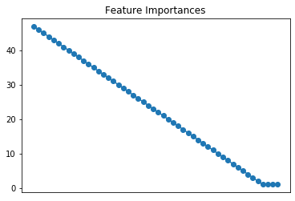

```python
# visualise result
coefs = pd.Series(selector.ranking_, X_train.columns).sort_values(ascending=False)
ax=coefs.plot(title='Feature Importances', marker='o', rot=90)
ax.axes.get_xaxis().set_visible(False)
print("Feature Ranking:\n %s"% coefs)
```

### Feature selection with Recursive Feature Elimination and a RandomForestRegressor

```python
from sklearn.ensemble import RandomForestRegressor

estimator = RandomForestRegressor(n_estimators=16, random_state=0)
selector = RFECV(estimator=estimator, cv=5)
selector = selector.fit(X_train, y_train)
```

```
Feature Ranking:
 Outlet_0                  35
Outlet_4                  34
Item_MRP_Category_1       33
Item_MRP_Category_2       32
Item_Type_11              31
Outlet_Type_2             30
Item_Type_12              29
Outlet_1                  28
Outlet_Type_1             27
Item_Fat_Content_1        26
Item_Type_1               25
Item_Type_7               24
Outlet_3                  23
Outlet_Size_0             22
Item_Type_2               21
Item_Type_15              20
Item_Type_Category_2      19
Outlet_Size_1             18
Outlet_Location_Type_1    17
Item_Type_8               16
Item_Type_Category_0      15
Item_MRP_Category_0       14
Item_Type_10              13
Item_Type_0               12
Outlet_Location_Type_2    11
Item_Type_14              10
Outlet_2                   9
Outlet_9                   8
Item_Type_3                7
Outlet_8                   6
Item_Type_9                5
Item_Type_4                4
Item_Type_5                3
Outlet_7                   2
Outlet_5                   1
Item_Visibility            1
Item_Weight                1
Outlet_Age                 1
Item_Fat_Content_0         1
Item_Fat_Content_2         1
Outlet_6                   1
Outlet_Location_Type_0     1
Item_MRP_Category_3        1
Item_Type_13               1
Item_Type_6                1
Item_Type_Category_1       1
Outlet_Type_3              1
Outlet_Type_0              1
Outlet_Size_2              1
Item_MRP                   1
dtype: int64
```

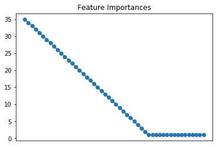

```python
# visualise result
coefs = pd.Series(selector.ranking_, X_train.columns).sort_values(ascending=False)
ax=coefs.plot(title='Feature Importances', marker='o', rot=90)
ax.axes.get_xaxis().set_visible(False)
print("Feature Ranking:\n %s"% coefs)
```

Item_Visibility

Outlet_Age

Item_MRP_Category_3

Outlet_Type_3

Outlet_Type_0

Item_MRP

```python
features = list(coefs.index[:16])
not_features = list(coefs.index[16:])
```

```python
with open('/Users/shusasaki/Documents/github/data_science_projects_editing/MartSales/modified_data/features.txt', 'w') as f:
    for item in features:
        f.write("%s\n" % item)
```

```python
with open('/Users/shusasaki/Documents/github/data_science_projects_editing/MartSales/modified_data/not_features.txt', 'w') as f:
    for item in not_features:
        f.write("%s\n" % item)
```

```python
X_train = X_train.drop(not_features, axis=1)
```

```python
X_test = X_test.drop(not_features, axis=1)
```

```python
test = test.drop(not_features, axis=1)
```

Note: Feature scaling is done better without data standardisation - see 'Big Mart Sales prediction_v3.ipynb'.

## Regression models

Here we create a generic function that takes the algorithm and data as input, makes the model, performs corss-validation and generates the submission files.

```python
# define target and ID columns
target = 'Item_Outlet_Sales'
IDcols = ['Item_Identifier', 'Outlet_Identifier']

from sklearn.model_selection import cross_val_score
from sklearn import metrics

def modelfit(model, X_train, X_test, y_train, y_test, dtest, IDcols, target, filename):

    # fit algorithm to data
    model.fit(X_train, y_train)

    # predict training set
#    train_preds = model.predict(X_train)
    val_preds = model.predict(X_test)

    # perform cross-validation
    cv_score = cross_val_score(model, X_train, y_train, cv=20, scoring='neg_mean_squared_error')
#    print(cv_score)
    cv_score = np.sqrt(np.abs(cv_score))
#    print(cv_score)

    # print model report
    print('\nModel Report')
#    print('Training dataset RMSE: %.4g' %np.sqrt(metrics.mean_squared_error(train_preds, y_train)))
    print('Validation dataset RMSE: %.4g' %np.sqrt(metrics.mean_squared_error(val_preds, y_test)))
    print('CV score: Mean and 95%% confidence interval  - %.4g (+/- %0.2f)| Std - %.4g | Min - %.4g | Max - %.4g' % (np.mean(cv_score),np.std(cv_score) * 2,np.std(cv_score),np.min(cv_score),np.max(cv_score)))
#    print("Accuracy: %0.2f (+/- %0.2f)" % (np.mean(cv_score), np.std(cv_score) * 2))

    # predictors
#    predictors = [x for x in dtest.columns if x not in [target]+IDcol]

    # prediction on testing data
    dtest[target] = model.predict(dtest[X_train.columns])

    # export submission file
    IDcols.append(target)
    submission = pd.DataFrame({x:dtest[x] for x in IDcols})
    #submission.to_csv(filename, index=False)
```

### Standard Regression Model

```python
test.head()
```

|  | Item_Identifier | Outlet_Identifier | Item_Fat_Content_1 | Item_Type_1 | Item_Type_2 | Item_Type_7 | Item_Type_11 | Item_Type_12 | Item_Type_15 | Outlet_Size_0 | Outlet_Type_1 | Outlet_Type_2 | Item_MRP_Category_1 | Item_MRP_Category_2 | Outlet_0 | Outlet_1 | Outlet_3 | Outlet_4 |
| --- | --- | --- | --- | --- | --- | --- | --- | --- | --- | --- | --- | --- | --- | --- | --- | --- | --- | --- |
| 8523 | FDW58 | OUT049 | 0 | 0 | 0 | 0 | 0 | 0 | 0 | 0 | 1 | 0 | 0 | 1 | 0 | 0 | 0 | 0 |
| 8524 | FDW14 | OUT017 | 0 | 0 | 0 | 0 | 0 | 0 | 0 | 0 | 1 | 0 | 0 | 1 | 0 | 0 | 0 | 0 |
| 8525 | NCN55 | OUT010 | 1 | 0 | 0 | 0 | 1 | 0 | 0 | 0 | 0 | 0 | 0 | 0 | 1 | 0 | 0 | 0 |
| 8526 | FDQ58 | OUT017 | 0 | 0 | 0 | 0 | 0 | 0 | 0 | 0 | 1 | 0 | 0 | 0 | 0 | 0 | 0 | 0 |
| 8527 | FDY38 | OUT027 | 0 | 0 | 0 | 0 | 0 | 0 | 0 | 0 | 0 | 0 | 0 | 0 | 0 | 0 | 0 | 0 |

```
Model Report
Validation dataset RMSE: 1143
CV score: Mean and 95% confidence interval  - 1222 (+/- 142.71)| Std - 71.35 | Min - 1028 | Max - 1312
```

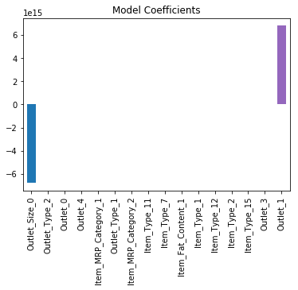

```python
from sklearn.linear_model import LinearRegression

filename = '/Users/shusasaki/Documents/data_science_projects/datasets/MartSales data/final_models/model4.csv'
model4 = LinearRegression(normalize=True)
modelfit(model4, X_train, X_test, y_train, y_test, test, IDcols, target, filename)

# visualise result
coef4 = pd.Series(model4.coef_, X_train.columns).sort_values()
coef4.plot(kind='bar', title='Model Coefficients')
```

By comparing the RMSE we can see that this model is better than the baseline model3. However, the coefficients are very large, which signifies overfitting. So we will next use a ridge regression model to regularise the magnitude of the coefficients of he features.

### Ridge Regression Model

```
Model Report
Validation dataset RMSE: 1143
CV score: Mean and 95% confidence interval  - 1222 (+/- 144.43)| Std - 72.21 | Min - 1026 | Max - 1314
```

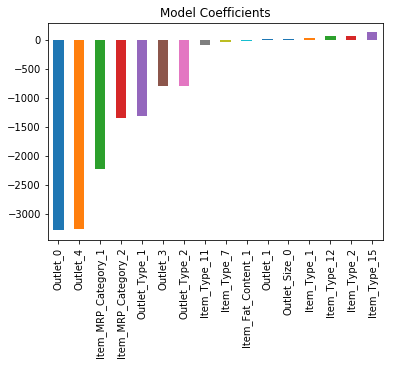

```python
from sklearn.linear_model import Ridge

#predictors = [x for x in train_num_cat_one_hot.columns if x not in [target]+IDcols]
filename = '/Users/shusasaki/Documents/data_science_projects/datasets/MartSales data/final_models/model5.csv'
model5 = Ridge(alpha=0.01, normalize=True)
modelfit(model5, X_train, X_test, y_train, y_test, test, IDcols, target, filename)


# visualise result
coef5 = pd.Series(model5.coef_, X_train.columns).sort_values()
coef5.plot(kind='bar', title='Model Coefficients')
```

The RMSE is only slightly better than with model4 and the CV scores are not very different.

Next, we not only regularize the magnitude of the coefficients but we also do feature selection, with Lasso Regression.

### Lasso Regression Model

```
Model Report
Validation dataset RMSE: 1143
CV score: Mean and 95% confidence interval  - 1222 (+/- 143.25)| Std - 71.63 | Min - 1026 | Max - 1313
```

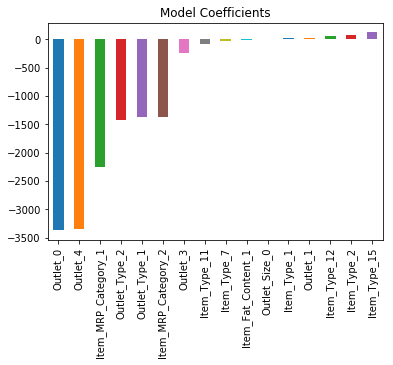

```python
from sklearn.linear_model import Lasso

filename = '/Users/shusasaki/Documents/data_science_projects/datasets/MartSales data/final_models/model6.csv'
model6 = Lasso(alpha=0.01, normalize=True)
modelfit(model6, X_train, X_test, y_train, y_test, test, IDcols, target, filename)

# visualise result
coef6 = pd.Series(model6.coef_, X_train.columns).sort_values()
coef6.plot(kind='bar', title='Model Coefficients')
```

Again, the RMSE is only slightly better than with model4 and model5 and the CV scores are not very different.

Now we try to tune the alpha parameter for both Ridge and Lasso Regression to see if we get improvement.

### Alpha parameter tuning for Ridge and Lasso Regression

```python
# function to run Ridge or Lasso Regressionwith difference values of alpha
def ridge_lasso_regression(alg, X_train, y_train, X_test, y_test, alpha):

    # define model
    if alg == 'Ridge':
        model = Ridge(alpha=alpha,normalize=True)
    else:
        model = Lasso(alpha=alpha,normalize=True, max_iter=1e2)

    # fit algorithm to data
    model.fit(X_train, y_train)

    # predict training set
    #train_predictions = model.predict(X_train)
    val_predictions = model.predict(X_test)

    # print the RSME
    print('\nModel Report for alpha={}'.format(alpha))
    #print('Training dataset RMSE: %.4g' %np.sqrt(metrics.mean_squared_error(y_train, train_predictions)))
    print('Validation dataset RMSE: %.4g' %np.sqrt(metrics.mean_squared_error(y_test, val_predictions)))
    RMSE=np.sqrt(metrics.mean_squared_error(y_test, val_predictions))

    # print cross validation
    cv_score = cross_val_score(model, X_train, y_train, cv=20, scoring='neg_mean_squared_error')
    cv_score = np.sqrt(np.abs(cv_score))
    print('CV score: Mean and 95%% confidence interval  - %.4g (+/- %0.2f)| Std - %.4g | Min - %.4g | Max - %.4g' % (np.mean(cv_score),np.std(cv_score) * 2,np.std(cv_score),np.min(cv_score),np.max(cv_score)))

    # visualise
    fig = plt.figure()
    coef = pd.Series(model.coef_, X_train.columns).sort_values()
    coef.plot(kind='bar', title='Model Coefficients with alpha {} and RSME: {}'.format(alpha, RMSE))
```

```
Model Report for alpha=1e-15
Validation dataset RMSE: 1144
CV score: Mean and 95% confidence interval  - 1222 (+/- 143.10)| Std - 71.55 | Min - 1027 | Max - 1313

Model Report for alpha=1e-10
Validation dataset RMSE: 1144
CV score: Mean and 95% confidence interval  - 1222 (+/- 143.10)| Std - 71.55 | Min - 1027 | Max - 1313

Model Report for alpha=1e-08
Validation dataset RMSE: 1144
CV score: Mean and 95% confidence interval  - 1222 (+/- 143.10)| Std - 71.55 | Min - 1027 | Max - 1313

Model Report for alpha=0.0001
Validation dataset RMSE: 1144
CV score: Mean and 95% confidence interval  - 1222 (+/- 143.11)| Std - 71.56 | Min - 1027 | Max - 1313

Model Report for alpha=0.001
Validation dataset RMSE: 1144
CV score: Mean and 95% confidence interval  - 1222 (+/- 143.24)| Std - 71.62 | Min - 1027 | Max - 1313

Model Report for alpha=0.01
Validation dataset RMSE: 1143
CV score: Mean and 95% confidence interval  - 1222 (+/- 144.43)| Std - 72.21 | Min - 1026 | Max - 1314

Model Report for alpha=1
Validation dataset RMSE: 1362
CV score: Mean and 95% confidence interval  - 1438 (+/- 153.92)| Std - 76.96 | Min - 1276 | Max - 1541

Model Report for alpha=5
Validation dataset RMSE: 1550
CV score: Mean and 95% confidence interval  - 1620 (+/- 145.40)| Std - 72.7 | Min - 1477 | Max - 1727

Model Report for alpha=10
Validation dataset RMSE: 1596
CV score: Mean and 95% confidence interval  - 1664 (+/- 143.28)| Std - 71.64 | Min - 1525 | Max - 1771

Model Report for alpha=20
Validation dataset RMSE: 1622
CV score: Mean and 95% confidence interval  - 1690 (+/- 142.08)| Std - 71.04 | Min - 1553 | Max - 1797
```

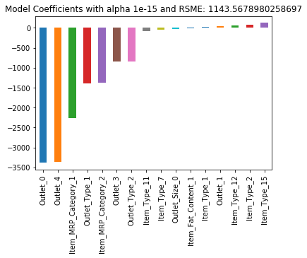

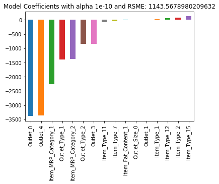

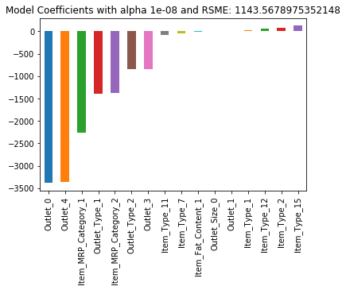

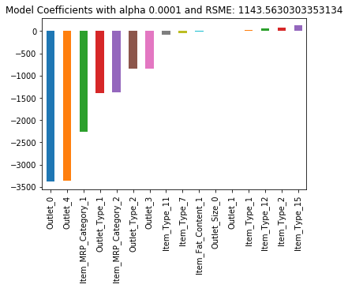

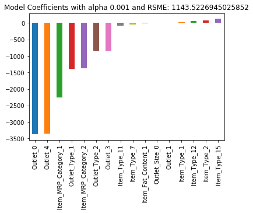

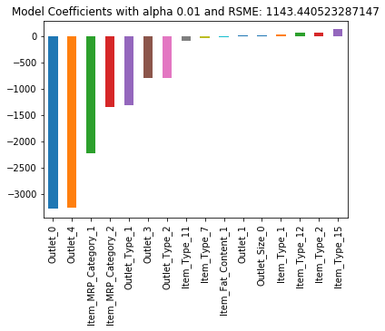

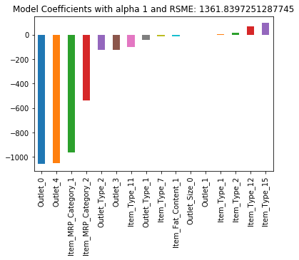

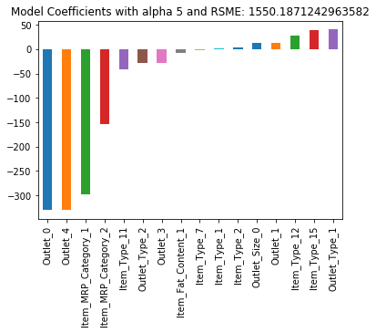

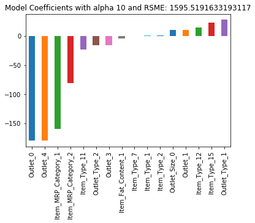

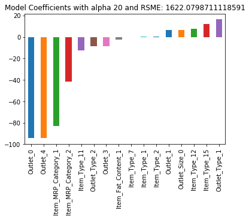

```python
# set the different values of alpha to be tested
alpha = [1e-15, 1e-10, 1e-8, 1e-4, 1e-3, 1e-2, 1, 5, 10, 20]

# run models
for i in range(10):
    ridge_lasso_regression('Ridge', X_train, y_train, X_test, y_test, alpha[i])
```

```
Model Report for alpha=1e-15
Validation dataset RMSE: 1144
```

```
CV score: Mean and 95% confidence interval  - 1222 (+/- 143.10)| Std - 71.55 | Min - 1027 | Max - 1313

Model Report for alpha=1e-10
Validation dataset RMSE: 1144
```

[output not shown]

[output cut: 17 more lines]

```
CV score: Mean and 95% confidence interval  - 1222 (+/- 143.10)| Std - 71.55 | Min - 1027 | Max - 1313

Model Report for alpha=1e-08
Validation dataset RMSE: 1144
```

[output not shown]

```
CV score: Mean and 95% confidence interval  - 1222 (+/- 143.10)| Std - 71.55 | Min - 1027 | Max - 1313

Model Report for alpha=0.0001
Validation dataset RMSE: 1144
```

[output not shown]

[output cut: 14 more lines]

```
CV score: Mean and 95% confidence interval  - 1222 (+/- 143.10)| Std - 71.55 | Min - 1027 | Max - 1313

Model Report for alpha=0.001
Validation dataset RMSE: 1144
```

[output not shown]

[output cut: 14 more lines]

```
CV score: Mean and 95% confidence interval  - 1222 (+/- 143.10)| Std - 71.55 | Min - 1027 | Max - 1313

Model Report for alpha=0.01
Validation dataset RMSE: 1143
CV score: Mean and 95% confidence interval  - 1222 (+/- 143.25)| Std - 71.63 | Min - 1026 | Max - 1313

Model Report for alpha=1
Validation dataset RMSE: 1199
CV score: Mean and 95% confidence interval  - 1274 (+/- 155.55)| Std - 77.77 | Min - 1086 | Max - 1376

Model Report for alpha=5
Validation dataset RMSE: 1525
CV score: Mean and 95% confidence interval  - 1582 (+/- 154.27)| Std - 77.13 | Min - 1432 | Max - 1698

Model Report for alpha=10
Validation dataset RMSE: 1652
CV score: Mean and 95% confidence interval  - 1719 (+/- 140.80)| Std - 70.4 | Min - 1584 | Max - 1826

Model Report for alpha=20
Validation dataset RMSE: 1652
CV score: Mean and 95% confidence interval  - 1719 (+/- 140.80)| Std - 70.4 | Min - 1584 | Max - 1826
```

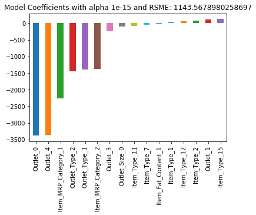

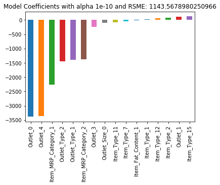

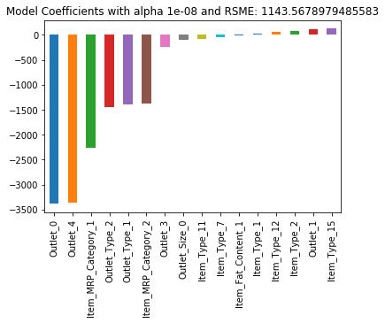

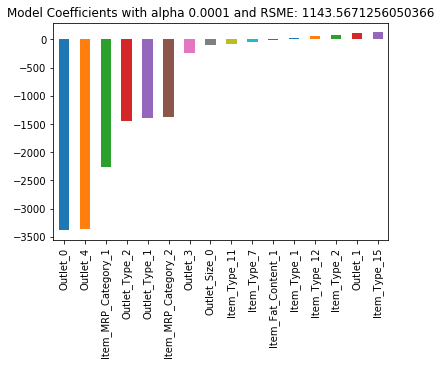

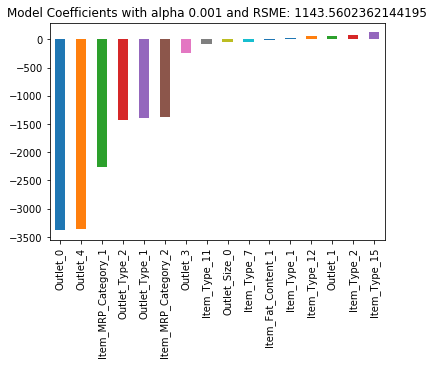

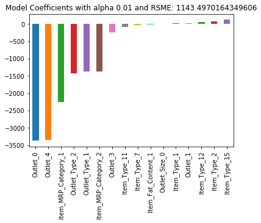

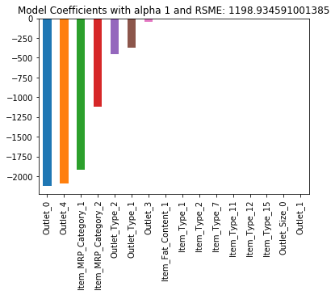

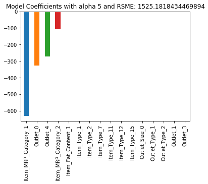

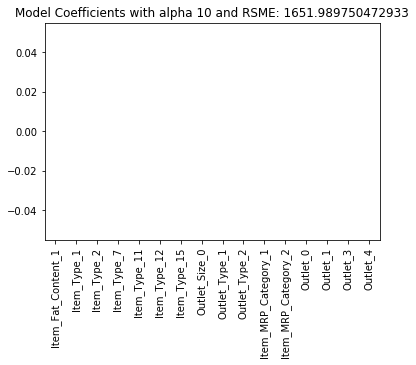

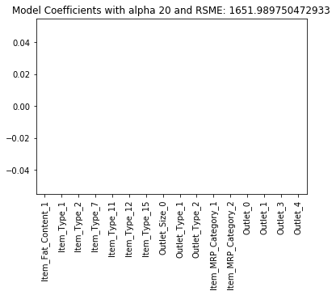

```python
for i in range(10):
    ridge_lasso_regression('Lasso', X_train, y_train, X_test, y_test, alpha[i])
```

We stick with 0.001.

Now we can explore other types of models; such as decision Trees, Random Forests, GBM, XGBoost and ensemble techniques.

## Tree models

Here we build a decision tree model and we use an ensemble method - Random Forest.

### Decision Tree Model

```
Model Report
Validation dataset RMSE: 1105
CV score: Mean and 95% confidence interval  - 1182 (+/- 150.79)| Std - 75.4 | Min - 978.1 | Max - 1283
```

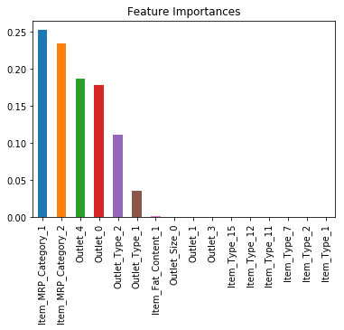

```python
# initial guess
from sklearn.tree import DecisionTreeRegressor

filename = '/Users/shusasaki/Documents/data_science_projects/datasets/MartSales data/final_models/v2/model7.csv'
model7 = DecisionTreeRegressor(max_depth=15, min_samples_leaf=100)
modelfit(model7, X_train, X_test, y_train, y_test, test, IDcols, target, filename)

# visualise result
coef7 = pd.Series(model7.feature_importances_, X_train.columns).sort_values(ascending=False)
coef7.plot(kind='bar', title='Feature Importances')
```

### Parameter tuning for DecisionTreeRegressor

```python
# function for parameter tunning
def decision_tree_regression_tune(model, X_train, y_train, X_test, y_test):

    # fit algorithm to data
    model.fit(X_train, y_train)

    # predict
    test_pred = model.predict(X_test)

    # RSME
    #print('Training dataset RMSE: %.4g' %np.sqrt(metrics.mean_squared_error(y_train, train_predictions)))
    #print('Validation dataset RMSE: %.4g' %np.sqrt(metrics.mean_squared_error(y_test, val_predictions)))
    RMSE=np.sqrt(metrics.mean_squared_error(y_test, test_pred))

    # cross validation
    cv_score = cross_val_score(model, X_train, y_train, cv=20, scoring='neg_mean_squared_error')
    cv_score = np.sqrt(np.abs(cv_score))
    #print('CV score: Mean and 95%% confidence interval  - %.4g (+/- %0.2f)| Std - %.4g | Min - %.4g | Max - %.4g' % (np.mean(cv_score),np.std(cv_score) * 2,np.std(cv_score),np.min(cv_score),np.max(cv_score)))
    cv_mean = np.mean(cv_score)

    return (RMSE, cv_mean)
```

To begin with, check all possible values for the parameters max_depth, min_samples_split and min_samples_leafs.

```python
max_depths=[1, 10, 1e2, 110, 120, 130, 140, 150, 160, 170, 180, 190, 200]
'''
max_depths=[1, 1e2, 110, 120, 130, 140, 150, 160, 170, 180, 190, 200]
min_samples_splits = np.linspace(0.1, 1.0, 10, endpoint=True)
min_samples_leafs = np.linspace(0.1, 0.5, 10, endpoint=True)
'''
train_results = []
test_results = []

for max_depth in max_depths:

    # define model
    model = DecisionTreeRegressor(max_depth=max_depth)

    rmse, cvmean = decision_tree_regression_tune(model, X_train, y_train, X_test, y_test)
    train_results.append(cvmean)
    test_results.append(rmse)


from matplotlib.legend_handler import HandlerLine2D
line1, = plt.plot(max_depths, train_results, 'b', label='Train cv_mean')
line2, = plt.plot(max_depths, test_results, 'r', label='Test RMSE')
plt.legend(handler_map={line1: HandlerLine2D(numpoints=2)})
plt.ylabel('RMSE')
plt.xlabel('Tree depth')
plt.show()
```

[output not shown]

In the next part of the analysis, let's choose values between 1 and 30.

```python
min_samples_splits = np.linspace(0.1, 1.0, 10, endpoint=True)
'''
max_depths=[1, 1e2, 110, 120, 130, 140, 150, 160, 170, 180, 190, 200]
min_samples_splits = np.linspace(0.1, 1.0, 10, endpoint=True)
min_samples_leafs = np.linspace(0.1, 0.5, 10, endpoint=True)
'''
train_results = []
test_results = []

for min_samples_split in min_samples_splits:

    # define model
    model = DecisionTreeRegressor(min_samples_split=min_samples_split)

    rmse, cvmean = decision_tree_regression_tune(model, X_train, y_train, X_test, y_test)
    train_results.append(cvmean)
    test_results.append(rmse)


from matplotlib.legend_handler import HandlerLine2D
line1, = plt.plot(min_samples_splits, train_results, 'b', label='Train cv_mean')
line2, = plt.plot(min_samples_splits, test_results, 'r', label='Test RMSE')
plt.legend(handler_map={line1: HandlerLine2D(numpoints=2)})
plt.ylabel('RMSE')
plt.xlabel('min_samples_splits')
plt.show()
```

[output not shown]

In the next part of the analysis, let's choose values between 0.001 and 0.07.

```python
min_samples_leafs = np.linspace(0.01, 0.5, 10, endpoint=True)
'''
max_depths=[1, 1e2, 110, 120, 130, 140, 150, 160, 170, 180, 190, 200]
min_samples_splits = np.linspace(0.1, 1.0, 10, endpoint=True)
min_samples_leafs = np.linspace(0.1, 0.5, 10, endpoint=True)
'''
train_results = []
test_results = []

for min_samples_leaf in min_samples_leafs:

    # define model
    model = DecisionTreeRegressor(min_samples_leaf=min_samples_leaf)

    rmse, cvmean = decision_tree_regression_tune(model, X_train, y_train, X_test, y_test)
    train_results.append(cvmean)
    test_results.append(rmse)


from matplotlib.legend_handler import HandlerLine2D
line1, = plt.plot(min_samples_leafs, train_results, 'b', label='Train cv_mean')
line2, = plt.plot(min_samples_leafs, test_results, 'r', label='Test RMSE')
plt.legend(handler_map={line1: HandlerLine2D(numpoints=2)})
plt.ylabel('RMSE')
plt.xlabel('min_samples_leaf')
plt.show()
```

[output not shown]

In the next part of the analysis, let's choose values between 0.01 and 0.011.

### Best Results

Run the model with a smaller set of values for each of the parameters.

```python
# function
def decision_tree_regression(X_train, y_train, X_test, y_test, max_depth, min_samples_split, min_samples_leaf):

    # define model
    model = DecisionTreeRegressor(max_depth=max_depth, min_samples_split=min_samples_split, min_samples_leaf=min_samples_leaf)

    # fit algorithm to data
    model.fit(X_train, y_train)

    # predict training set
    val_predictions = model.predict(X_test)

    # RSME
    RMSE=np.sqrt(metrics.mean_squared_error(y_test, val_predictions))

    # cross validation
    cv_score = cross_val_score(model, X_train, y_train, cv=20, scoring='neg_mean_squared_error')
    cv_score = np.sqrt(np.abs(cv_score))

    return (RMSE, np.mean(cv_score), max_depth, min_samples_leaf)
```

```python
# set the different values of max_depth and min_samples_leaf to be tested
max_depths = np.linspace(1, 30, 10, endpoint=True)
min_samples_splits = np.linspace(0.001, 0.07, 10, endpoint=True)
min_samples_leafs = np.linspace(0.01, 0.011, 10, endpoint=True)

training_score = []
test_score = []
depth = []
leaf = []
# run models
for max_depth in max_depths:
    for min_samples_split in min_samples_splits:
        for min_samples in min_samples_leafs:
            trainres, testres, depthres, leafres = decision_tree_regression(X_train, y_train, X_test, y_test,
                                                                            max_depth, min_samples_split, min_samples)
            training_score.append(trainres)
            test_score.append(testres)
            depth.append(depthres)
            leaf.append(leafres)
```

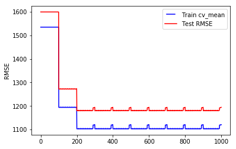

```python
from matplotlib.legend_handler import HandlerLine2D
line1, = plt.plot(np.linspace(0,len(training_score),len(training_score)), training_score, 'b', label='Train cv_mean')
line2, = plt.plot(np.linspace(0,len(test_score),len(test_score)), test_score, 'r', label='Test RMSE')
plt.legend(handler_map={line1: HandlerLine2D(numpoints=2)})
plt.ylabel('RMSE')
#plt.xlabel('Tree depth')
plt.show()
```

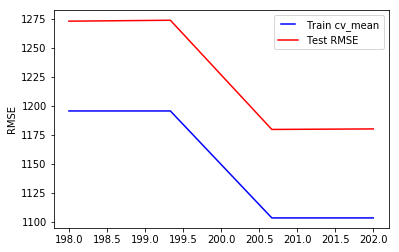

```python
from matplotlib.legend_handler import HandlerLine2D
yytrain = training_score[198:202]
yytest = test_score[198:202]
xx = np.linspace(198, 202, len(yytrain))

line1, = plt.plot(xx, yytrain, 'b', label='Train cv_mean')
line2, = plt.plot(xx, yytest, 'r', label='Test RMSE')
plt.legend(handler_map={line1: HandlerLine2D(numpoints=2)})
plt.ylabel('RMSE')
#plt.xlabel('Tree depth')
plt.show()
```

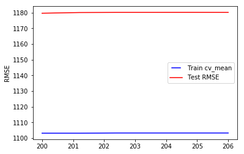

```python
from matplotlib.legend_handler import HandlerLine2D
yytrain = training_score[200:206]
yytest = test_score[200:206]
xx = np.linspace(200, 206, len(yytrain))

line1, = plt.plot(xx, yytrain, 'b', label='Train cv_mean')
line2, = plt.plot(xx, yytest, 'r', label='Test RMSE')
plt.legend(handler_map={line1: HandlerLine2D(numpoints=2)})
plt.ylabel('RMSE')
#plt.xlabel('Tree depth')
plt.show()
```

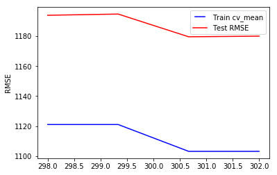

```python
from matplotlib.legend_handler import HandlerLine2D
yytrain = training_score[298:302]
yytest = test_score[298:302]
xx = np.linspace(298, 302, len(yytrain))

line1, = plt.plot(xx, yytrain, 'b', label='Train cv_mean')
line2, = plt.plot(xx, yytest, 'r', label='Test RMSE')
plt.legend(handler_map={line1: HandlerLine2D(numpoints=2)})
plt.ylabel('RMSE')
#plt.xlabel('Tree depth')
plt.show()
```

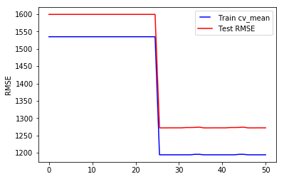

```python
from matplotlib.legend_handler import HandlerLine2D
line1, = plt.plot(np.linspace(0,len(training_score[75:125]),len(training_score[75:125])), training_score[75:125], 'b', label='Train cv_mean')
line2, = plt.plot(np.linspace(0,len(test_score[75:125]),len(test_score[75:125])), test_score[75:125], 'r', label='Test RMSE')
plt.legend(handler_map={line1: HandlerLine2D(numpoints=2)})
plt.ylabel('RMSE')
#plt.xlabel('Tree depth')
plt.show()
```

From this graph we have two interesting observations:

```python
# find the first smallest RMSE occurance
np.argmin(test_score)
```

```
300
```

```python
np.argmin(training_score)
```

```
280
```

```python
test_score[np.argmin(test_score)]
```

```
1179.6110258583153
```

```python
test_score[np.argmin(training_score)]
```

```
1180.0495328055745
```

```python
training_score[np.argmin(training_score)]
```

```
1103.0763744626483
```

```python
training_score[np.argmin(test_score)]
```

```
1103.1993786079115
```

```python
depth[np.argmin(training_score)]
```

```
7.444444444444445
```

```python
depth[np.argmin(test_score)]
```

```
10.666666666666668
```

```python
leaf[np.argmin(training_score)]
```

```
0.01
```

```python
leaf[np.argmin(test_score)]
```

```
0.01
```

```
Model Report
Validation dataset RMSE: 1103
CV score: Mean and 95% confidence interval  - 1180 (+/- 151.02)| Std - 75.51 | Min - 975.5 | Max - 1282
```

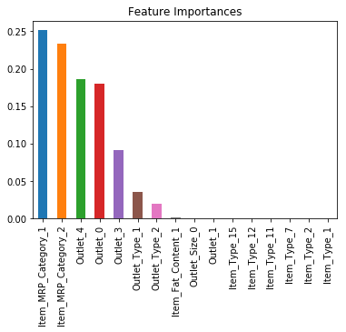

```python
from sklearn.tree import DecisionTreeRegressor

filename = '/Users/shusasaki/Documents/data_science_projects/datasets/MartSales data/final_models/v2/model8.csv'
model8 = DecisionTreeRegressor(max_depth=depth[np.argmin(test_score)], min_samples_leaf=leaf[np.argmin(test_score)])
modelfit(model8, X_train, X_test, y_train, y_test, test, IDcols, target, filename)

# visualise result
coef8 = pd.Series(model8.feature_importances_, X_train.columns).sort_values(ascending=False)
coef8.plot(kind='bar', title='Feature Importances')
```

## Neural Network

We tested the following learning rates: 0.00000001, 0.0000001, 0.000001, 0.001, 0.01, 1

and the following network architectures: (the table below shows the validation set RMSE)

[output not shown]

```python
# import data
train_s = pd.read_csv('/Users/shusasaki/Documents/github/data_science_projects_editing/MartSales/modified_data/train_s.csv')
test_s = pd.read_csv('/Users/shusasaki/Documents/github/data_science_projects_editing/MartSales/modified_data/test_s.csv')

train_s = train_s.drop(['Item_Identifier', 'Outlet_Identifier'], axis=1)
test_s = test_s.drop(['Item_Identifier', 'Outlet_Identifier'], axis=1)

# separate data into train and test sets
from sklearn.model_selection import train_test_split

X_train_s, X_test_s, y_train_s, y_test_s = train_test_split(train_s.loc[:, train_s.columns != 'Item_Outlet_Sales'], train_s['Item_Outlet_Sales'], test_size=0.2, random_state=42)

# get chosen features
file = '/Users/shusasaki/Documents/github/data_science_projects_editing/MartSales/modified_data/features.txt'
with open(file, 'r') as f:
    features = f.readlines()
features = [x[:-1] for x in features]

file = '/Users/shusasaki/Documents/github/data_science_projects_editing/MartSales/modified_data/not_features.txt'
with open(file, 'r') as f:
    not_features = f.readlines()
not_features = [x[:-1] for x in not_features]

X_train_s = X_train_s.drop(not_features, axis=1)
X_test_s = X_test_s.drop(not_features, axis=1)
test_s = test_s.drop(not_features, axis=1)
```

```python
# import modules
# Import necessary modules
import keras
from keras.layers import Dense
from keras.models import Sequential
from keras.optimizers import SGD
from keras.callbacks import EarlyStopping

from sklearn.model_selection import cross_val_score
from sklearn import metrics

# define variables
from sklearn.model_selection import cross_val_score
from sklearn import metrics
```

```python
# define functions
def get_new_model(layers=1, nodes=100):

    # Set up the model: model
    model = Sequential()

    # Add the first layer
    model.add(Dense(nodes, activation='relu', input_shape=(n_cols,)))

    # Add mode layers
    if layers==2:
        model.add(Dense(100, activation='relu'))
    elif layers==3:
        model.add(Dense(100, activation='relu'))
        model.add(Dense(100, activation='relu'))
    elif layers==4:
        model.add(Dense(n_rows, activation='relu'))
        model.add(Dense(n_rows, activation='relu'))
        model.add(Dense(n_rows, activation='relu'))
        model.add(Dense(n_rows, activation='relu'))

    # Add the output layer
    model.add(Dense(1))

    return(model)


def modelfit(model, lr, predictors, predictors_test, target, target_test):

    # Create SGD optimizer with specified learning rate: my_optimizer
    my_optimizer = SGD(lr=lr)

    # Compile the model
    model.compile(optimizer=my_optimizer, loss='mean_squared_error', metrics=['MSE'])

    # Define early_stopping_monitor
    early_stopping_monitor = EarlyStopping(patience=2)

    # Fit the model
    model.fit(predictors, target, epochs=100, callbacks=[early_stopping_monitor])
#    hist = model.fit(predictors, target, validation_split=0.3, epochs=100, callbacks=[early_stopping_monitor])

    # predict training set
    predictions = model.predict(predictors_test)

    # print model report
    print('\nModel Report')
    print('Validation dataset RMSE: %.4g' %np.sqrt(metrics.mean_squared_error(predictions, target_test)))
```

```
Model Report
Validation dataset RMSE: 1127
```

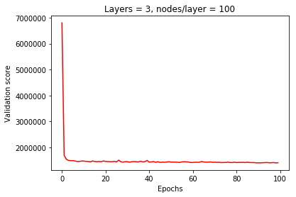

```python
#define variables
predictors = X_train_s
target = y_train_s
n_rows = predictors.shape[0]
n_cols = predictors.shape[1]
lr = 0.000001
layers = 3
nodes = 100

# Build new model to test, unaffected by previous models
model = get_new_model(layers=layers, nodes=nodes)

# fit model
modelfit(model, lr, predictors, X_test_s, target, y_test_s)

# Create the plot
plt.plot(model.history.history['mean_squared_error'], 'r')
plt.xlabel('Epochs')
plt.ylabel('Validation score')
plt.title('Layers = {}, nodes/layer = {}'.format(layers, nodes))
plt.show()
```